# Survey statistics

# Background and goals

Data from multiple student and alumni surveys is available, and there is some (incomplete) overlap between the population of survey respondents and email recipients.

- Exit survey: attitudes about KSM measured at the time of graduation, measured on a 5-point (2013) or 10-point (later) scale
- Network survey: most recent attitudes about the KSM alumni network measured at different times (looks like since 2017)

I expect attitude to influence email open/click rates; anecdotally, people with excellent and or experiences are most likely to give feedback, and that effect could appear in this dataset.

I’m also interested in looking at whether the three NPS categories of promoter, passive, and detractor are supported by the data or whether the raw (rescaled) values are more informative.

# Exit survey

Since the NPS scale changed from 5 points to 10 points I rescaled the responses to 0-10. It’s also possible to look at them as an ordered factor.

Exit survey data is available for 730 of the 1616 total alumni.

| NPS (rescaled) | 2 | 3 | 4 | 5 | 6 | 7 | 8 | 9 | 10 |  |
| --- | --- | --- | --- | --- | --- | --- | --- | --- | --- | --- |
| Count | 2 | 3 | 9 | 9 | 47 | 31 | 147 | 102 | 380 | 886 |

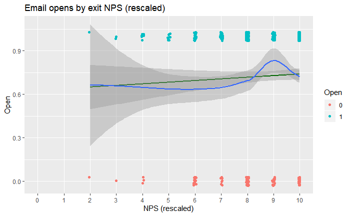

That bump at 9 is almost certainly due to 9 not being a valid rescaled value in the 2013 results. Breaking this down by email group (which also breaks out the 5-point 2013 class):

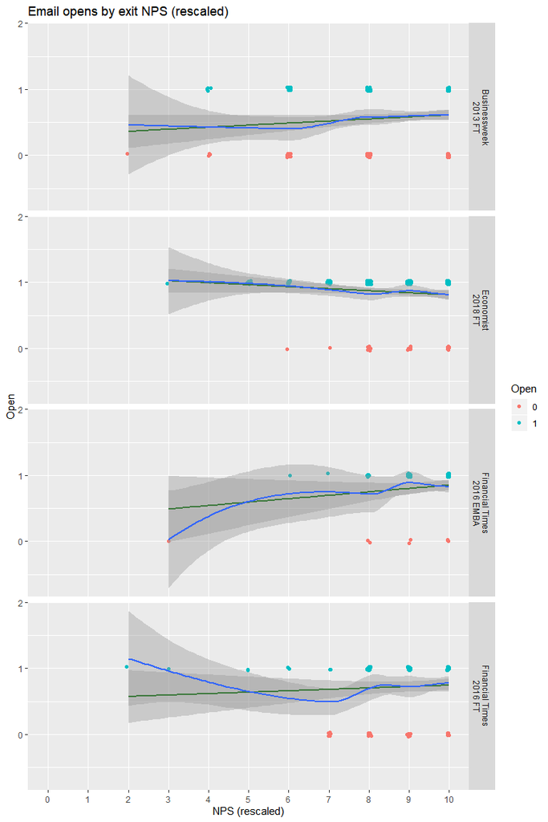

The eyeball test doesn’t find a consistent pattern. Low NPS scores appear to be outliers. Looking at the raw data:

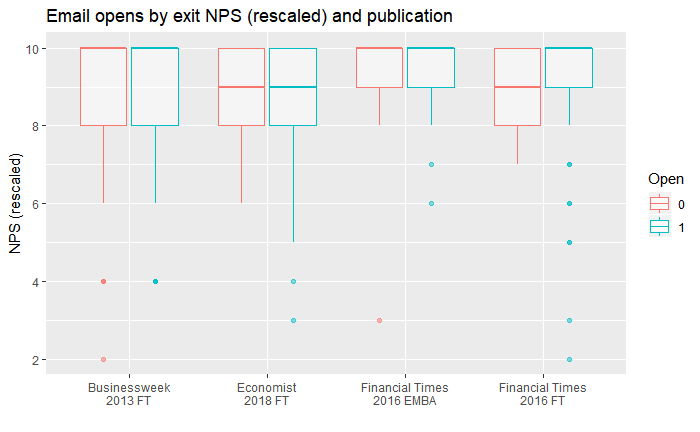

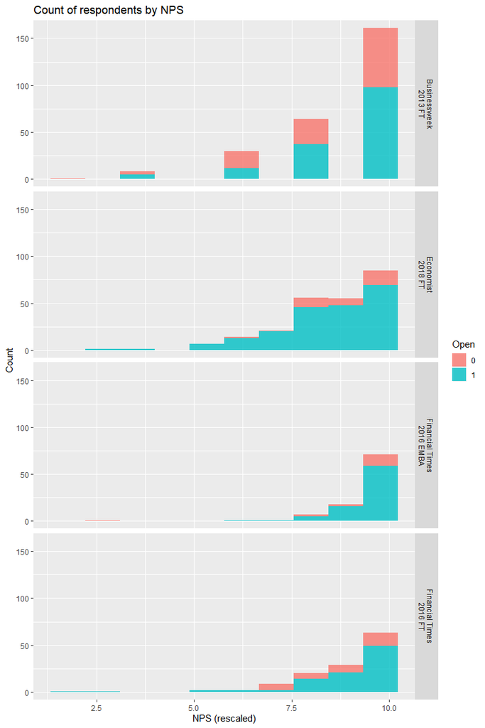

| email_group_filled | any_open | 2 | 3 | 4 | 5 | 6 | 7 | 8 | 9 | 10 |
| --- | --- | --- | --- | --- | --- | --- | --- | --- | --- | --- |
| Businessweek 2013 FT | 0 | 1 | 0 | 3 | 0 | 18 | 0 | 27 | 0 | 63 |
| Businessweek 2013 FT | 1 | 0 | 0 | 5 | 0 | 12 | 0 | 37 | 0 | 98 |
| Economist 2018 FT | 0 | 0 | 0 | 0 | 0 | 1 | 1 | 10 | 7 | 16 |
| Economist 2018 FT | 1 | 0 | 1 | 1 | 7 | 13 | 20 | 46 | 48 | 69 |
| Financial Times 2016 EMBA | 0 | 0 | 1 | 0 | 0 | 0 | 0 | 2 | 2 | 12 |
| Financial Times 2016 EMBA | 1 | 0 | 0 | 0 | 0 | 1 | 1 | 5 | 16 | 59 |
| Financial Times 2016 FT | 0 | 0 | 0 | 0 | 0 | 0 | 7 | 6 | 8 | 14 |
| Financial Times 2016 FT | 1 | 1 | 1 | 0 | 2 | 2 | 2 | 14 | 21 | 49 |

And the proportions:

| email_group_filled | 2 | 3 | 4 | 5 | 6 | 7 | 8 | 9 | 10 |
| --- | --- | --- | --- | --- | --- | --- | --- | --- | --- |
| Businessweek 2013 FT | 0% | 0% | 62.5% | 0% | 40% | 0% | 57.8% | 0% | 60.9% |
| Economist 2018 FT | 0% | 100% | 100% | 100% | 92.9% | 95.2% | 82.1% | 87.3% | 81.2% |
| Financial Times 2016 EMBA | 0% | 0% | 0% | 0% | 100% | 100% | 71.4% | 88.9% | 83.1% |
| Financial Times 2016 FT | 100% | 100% | 0% | 100% | 100% | 22.2% | 70% | 72.4% | 77.8% |

Looking instead at the NPS bins.

| email_group_filled | any_open | Detractor | Passive | Promoter |
| --- | --- | --- | --- | --- |
| Businessweek 2013 FT | 0 | 22 | 27 | 63 |
| Businessweek 2013 FT | 1 | 17 | 37 | 98 |
| Economist 2018 FT | 0 | 1 | 11 | 23 |
| Economist 2018 FT | 1 | 22 | 66 | 117 |
| Financial Times 2016 EMBA | 0 | 1 | 2 | 14 |
| Financial Times 2016 EMBA | 1 | 1 | 6 | 75 |
| Financial Times 2016 FT | 0 | 0 | 13 | 22 |
| Financial Times 2016 FT | 1 | 6 | 16 | 70 |

| email_group_filled | Detractor | Passive | Promoter |
| --- | --- | --- | --- |
| Businessweek 2013 FT | 43.6% | 57.8% | 60.9% |
| Economist 2018 FT | 95.7% | 85.7% | 83.6% |
| Financial Times 2016 EMBA | 50% | 75% | 84.3% |
| Financial Times 2016 FT | 100% | 55.2% | 76.1% |

Again, not very consistent, though the number of detractors overall is very small.

Redoing the above chart with just full-time:

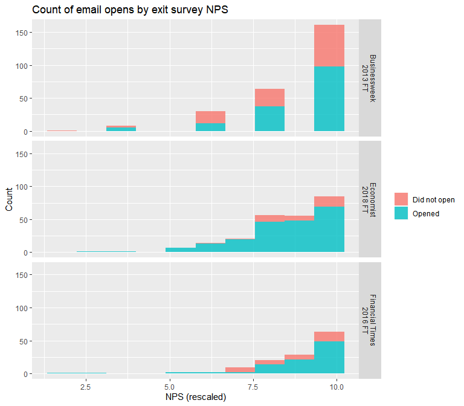

| email_group_filled | exit_survey | open_pct |
| --- | --- | --- |
| Businessweek 2013 FT | FALSE | 0.5757576 |
| Businessweek 2013 FT | TRUE | 0.5045872 |
| Economist 2018 FT | FALSE | 0.8541667 |
| Economist 2018 FT | TRUE | 0.8410042 |
| Financial Times 2016 EMBA | FALSE | 0.8282828 |
| Financial Times 2016 EMBA | TRUE | 0.8172043 |
| Financial Times 2016 FT | FALSE | 0.7244094 |
| Financial Times 2016 FT | TRUE | 0.5744048 |

# Network survey

(Need to understand this data better - is 0 a score or how they coded missing values?)